# Homework Assignment 4: Tidy Data and Joins

Hannah McSorley

Due 2019-10-08

## Assignment Objective

The focus of this assignment is to practice problem solving in R using two key components of data wrangling: data aggregation and reshaping. In addition, data visualization with ggplo2 will be included. The data used in this assignment includes ‘gapminder’ (for Exercises 1 & 2), and two wedding-planning data sets (for Exercise 3).

```r
library(tidyverse)
library(gapminder)
library(knitr)  # for tidy tables
library(DT)     # for datatable in html
```

# Exercise 1: Univariate Data Reshaping

**Option 2**

Three Goals:

- 1. Reshape data into wider format
- 2. Produce a plot of the wide data
- 3. Re-lengthening the wider data

This code creates two wide tibbles, with years/continents as either rows or columns.

```r
# mutate and reshape data into wider format
## use tidyr::pivot_wider()
# A: rows = year, columns = continents
A_wide <- gapminder %>%
  dplyr::arrange(continent, year) %>%
  group_by(continent, year) %>%
  summarize(med_lifeExp = median(lifeExp)) %>%
  tidyr::pivot_wider(id_cols = year,
                         names_from = continent,
                         values_from = med_lifeExp)
# table
knitr::kable(A_wide, digits = 0,
      caption = "Table 1A-Wide: continental median life expectancy")
```

Table 1A-Wide: continental median life expectancy

| year | Africa | Americas | Asia | Europe | Oceania |
| --- | --- | --- | --- | --- | --- |
| 1952 | 39 | 55 | 45 | 66 | 69 |
| 1957 | 41 | 56 | 48 | 68 | 70 |
| 1962 | 43 | 58 | 49 | 70 | 71 |
| 1967 | 45 | 61 | 54 | 71 | 71 |
| 1972 | 47 | 63 | 57 | 71 | 72 |
| 1977 | 49 | 66 | 61 | 72 | 73 |
| 1982 | 51 | 67 | 64 | 73 | 74 |
| 1987 | 52 | 69 | 66 | 75 | 75 |
| 1992 | 52 | 70 | 69 | 75 | 77 |
| 1997 | 53 | 72 | 70 | 76 | 78 |
| 2002 | 51 | 72 | 71 | 78 | 80 |
| 2007 | 53 | 73 | 72 | 79 | 81 |

```r
# B: rows = continents, columns = years
B_wide <- gapminder %>%
  dplyr::arrange(continent, year) %>%
  group_by(continent, year) %>%
  summarize(med_lifeExp = median(lifeExp)) %>%
  tidyr::pivot_wider(id_cols = continent,
                         names_from = year,
                         values_from = med_lifeExp)
# table
knitr::kable(B_wide, digits = 0,
      caption = "Table 1B-Wide: median life expectancy over time by continent")
```

Table 1B-Wide: median life expectancy over time by continent

| continent | 1952 | 1957 | 1962 | 1967 | 1972 | 1977 | 1982 | 1987 | 1992 | 1997 | 2002 | 2007 |
| --- | --- | --- | --- | --- | --- | --- | --- | --- | --- | --- | --- | --- |
| Africa | 39 | 41 | 43 | 45 | 47 | 49 | 51 | 52 | 52 | 53 | 51 | 53 |
| Americas | 55 | 56 | 58 | 61 | 63 | 66 | 67 | 69 | 70 | 72 | 72 | 73 |
| Asia | 45 | 48 | 49 | 54 | 57 | 61 | 64 | 66 | 69 | 70 | 71 | 72 |
| Europe | 66 | 68 | 70 | 71 | 71 | 72 | 73 | 75 | 75 | 76 | 78 | 79 |
| Oceania | 69 | 70 | 71 | 71 | 72 | 73 | 74 | 75 | 77 | 78 | 80 | 81 |

Visually, it might be more intuitive to read Table 1B-Wide, with years progressing from left to right. However, it seems difficult to plot from that tibble shape, especially because the variables are numbers (years).

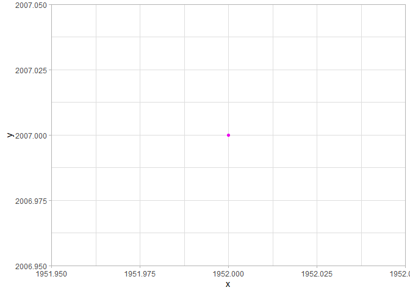

```r
# Produce a plot of (some of) the wide data
# B (easy to read)
B_wide %>% ggplot(aes(x = 1952, y = 2007)) +
  geom_point(colour = "magenta2") +
  theme_light()
```

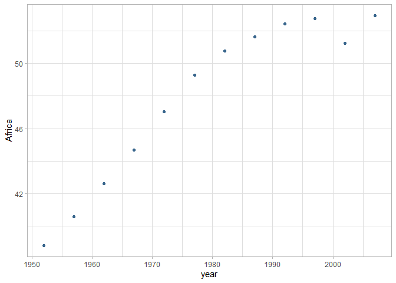

```r
# the data from Table 1-B is difficult to plot (at least for me)
# the variables are numbers (years), and are treated as discrete numbers in ggplot

# try plotting the data from Table 1A-Wide
# A
A_wide %>% ggplot(aes(x = year, y = Africa)) +
  geom_point(colour = "steelblue4") +
  theme_light()
```

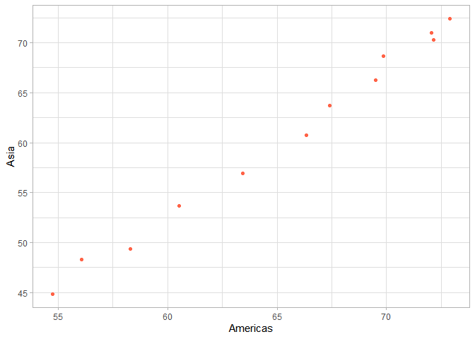

```r
# it's easier to plot a contient's median life expectancy over time from Table 1-A
# trickier to plot multiple contients over time though...that's easier from long format

# easy to plot one continent against another
A_wide %>% ggplot(aes(x = Americas, y = Asia)) +
  geom_point(colour = "tomato") +
  theme_light()
```

It seems that the data shape which is easiest to read, or most intuitive to present, is the most difficult to plot in R. Whereas longer tibbles are easier for R to read and plot.

```r
# Re-lengthening the wider data
## use tidyr::pivot_longer()
#A
A_long <- A_wide %>%
  tidyr::pivot_longer(cols = Africa:Oceania,
                      names_to = "continent",
                      values_to = "median_lifeExp") %>%
  arrange(continent)
# table
DT::datatable(A_long, caption = "Table 1A-Long: continental median life expectancy")
```

|  | year | continent | median_lifeExp |
| --- | --- | --- | --- |
| 1 | 1952 | Africa | 38.833 |
| 2 | 1957 | Africa | 40.5925 |
| 3 | 1962 | Africa | 42.6305 |
| 4 | 1967 | Africa | 44.6985 |
| 5 | 1972 | Africa | 47.0315 |
| 6 | 1977 | Africa | 49.2725 |
| 7 | 1982 | Africa | 50.756 |
| 8 | 1987 | Africa | 51.6395 |
| 9 | 1992 | Africa | 52.429 |
| 10 | 1997 | Africa | 52.759 |

[output cut: 50 more lines]

```r
# check that you produced what you wanted:
gapminder %>%
  dplyr::arrange(continent, year) %>%
  group_by(continent, year) %>%
  summarize(med_lifeExp = median(lifeExp))
```

```
## # A tibble: 60 x 3
## # Groups:   continent [5]
##    continent  year med_lifeExp
##    <fct>     <int>       <dbl>
##  1 Africa     1952        38.8
##  2 Africa     1957        40.6
##  3 Africa     1962        42.6
##  4 Africa     1967        44.7
##  5 Africa     1972        47.0
##  6 Africa     1977        49.3
##  7 Africa     1982        50.8
##  8 Africa     1987        51.6
##  9 Africa     1992        52.4
## 10 Africa     1997        52.8
## # ... with 50 more rows
```

```r
# Yes!

# Re-lengthen the data from Table 1-B also
B_long <- B_wide %>%
  tidyr::pivot_longer(cols = (2:13),
                      names_to = "year",
                      values_to = "median_lifeExp") %>%
  arrange(continent)
# table
DT::datatable(B_long, caption = "Table 1B-Long: continental median life expectancy")
```

|  | continent | year | median_lifeExp |
| --- | --- | --- | --- |
| 1 | Africa | 1952 | 38.833 |
| 2 | Africa | 1957 | 40.5925 |
| 3 | Africa | 1962 | 42.6305 |
| 4 | Africa | 1967 | 44.6985 |
| 5 | Africa | 1972 | 47.0315 |
| 6 | Africa | 1977 | 49.2725 |
| 7 | Africa | 1982 | 50.756 |
| 8 | Africa | 1987 | 51.6395 |
| 9 | Africa | 1992 | 52.429 |
| 10 | Africa | 1997 | 52.759 |

[output cut: 50 more lines]

# Exercise 2: Multivariate Data Reshaping

Two Goals:

- 1. Reshape data into wider format
- 2. Re-lengthening the wider data

**Option 1** *Specifically*

- 1. Make a tibble with one row per year, and columns for life expectancy and GDP per capita (or two other numeric variables) for two or more countries.
- 2. Re-lengthen the data

```r
# filter for two countries' lifeExp & gdpPercap
# pivot_wider()
# then pivot back (pivot_longer())
E2_wide <- gapminder %>%
  dplyr::arrange(country, year) %>%
  select(-pop, -continent) %>%
  filter(country == "Guinea" |
           country == "Slovenia") %>%
  pivot_wider(id_cols = year,
              names_from = country,
              values_from = c(lifeExp, gdpPercap))
knitr::kable(E2_wide, digits = c(0, 0, 0, 2, 2),
             caption = "Wide format: multivariate countries' GDP and life expectancy")
```

Wide format: multivariate countries’ GDP and life expectancy

| year | lifeExp_Guinea | lifeExp_Slovenia | gdpPercap_Guinea | gdpPercap_Slovenia |
| --- | --- | --- | --- | --- |
| 1952 | 34 | 66 | 510.20 | 4215.04 |
| 1957 | 35 | 68 | 576.27 | 5862.28 |
| 1962 | 36 | 69 | 686.37 | 7402.30 |
| 1967 | 37 | 69 | 708.76 | 9405.49 |
| 1972 | 39 | 70 | 741.67 | 12383.49 |
| 1977 | 41 | 71 | 874.69 | 15277.03 |
| 1982 | 43 | 71 | 857.25 | 17866.72 |
| 1987 | 46 | 72 | 805.57 | 18678.53 |
| 1992 | 49 | 74 | 794.35 | 14214.72 |
| 1997 | 51 | 75 | 869.45 | 17161.11 |
| 2002 | 54 | 77 | 945.58 | 20660.02 |
| 2007 | 56 | 78 | 942.65 | 25768.26 |

Take the wider tibble and pivot it back to long format.

```r
# filter for two countries' lifeExp & gdpPercap
# pivot_wider()
# then pivot back (pivot_longer())
E2_longer <- E2_wide %>%
   pivot_longer(cols = -year,
              names_to = c(".value", "Country"),
              names_sep = "_",
              values_to = c("lifeExp", "gdpPercap")) %>%
   arrange(Country)
knitr::kable(E2_longer, digits = c(0, 0, 0, 2, 2),
             caption = "Wide format: multivariate countries' GDP and life expectancy")
```

| year | Country | lifeExp | gdpPercap |
| --- | --- | --- | --- |
| 1952 | Guinea | 34 | 510.20 |
| 1957 | Guinea | 35 | 576.27 |
| 1962 | Guinea | 36 | 686.37 |
| 1967 | Guinea | 37 | 708.76 |
| 1972 | Guinea | 39 | 741.67 |
| 1977 | Guinea | 41 | 874.69 |
| 1982 | Guinea | 43 | 857.25 |
| 1987 | Guinea | 46 | 805.57 |
| 1992 | Guinea | 49 | 794.35 |
| 1997 | Guinea | 51 | 869.45 |
| 2002 | Guinea | 54 | 945.58 |
| 2007 | Guinea | 56 | 942.65 |
| 1952 | Slovenia | 66 | 4215.04 |
| 1957 | Slovenia | 68 | 5862.28 |
| 1962 | Slovenia | 69 | 7402.30 |
| 1967 | Slovenia | 69 | 9405.49 |
| 1972 | Slovenia | 70 | 12383.49 |
| 1977 | Slovenia | 71 | 15277.03 |
| 1982 | Slovenia | 71 | 17866.72 |
| 1987 | Slovenia | 72 | 18678.53 |
| 1992 | Slovenia | 74 | 14214.72 |
| 1997 | Slovenia | 75 | 17161.11 |
| 2002 | Slovenia | 77 | 20660.02 |
| 2007 | Slovenia | 78 | 25768.26 |

# Exercise 3: Table Joins

Read in the made-up wedding guestlist and email addresses:

```r
guest <- read_csv("https://raw.githubusercontent.com/STAT545-UBC/Classroom/master/data/wedding/attend.csv")
email <- read_csv("https://raw.githubusercontent.com/STAT545-UBC/Classroom/master/data/wedding/emails.csv")
# check the top of each data set:
head(guest)
```

```
## # A tibble: 6 x 7
##   party name  meal_wedding meal_brunch attendance_wedd~ attendance_brun~
##   <dbl> <chr> <chr>        <chr>       <chr>            <chr>
## 1     1 Somm~ PENDING      PENDING     PENDING          PENDING
## 2     1 Phil~ vegetarian   Menu C      CONFIRMED        CONFIRMED
## 3     1 Blan~ chicken      Menu A      CONFIRMED        CONFIRMED
## 4     1 Emaa~ PENDING      PENDING     PENDING          PENDING
## 5     2 Blai~ chicken      Menu C      CONFIRMED        CONFIRMED
## 6     2 Nige~ <NA>         <NA>        CANCELLED        CANCELLED
## # ... with 1 more variable: attendance_golf <chr>
```

```r
head(email)
```

```
## # A tibble: 6 x 2
##   guest                                                   email
##   <chr>                                                   <chr>
## 1 Sommer Medrano, Phillip Medrano, Blanka Medrano, Emaan~ sommm@gmail.com
## 2 Blair Park, Nigel Webb                                  bpark@gmail.com
## 3 Sinead English                                          singlish@hotmail~
## 4 Ayra Marks                                              marksa42@gmail.c~
## 5 Jolene Welsh, Hayley Booker                             jw1987@hotmail.c~
## 6 Amayah Sanford, Erika Foley                             erikaaaaaa@gmail~
```

## 3.1

For each guest in the guestlist (guest tibble), add a column for email address, which can be found in the email tibble.

*Note:* Before joining these tibbles, I separated names that were listed (probably by wedding party) in the tibble ‘email’. I found how to use ‘strsplit()’ with ‘unlist()’ to accomplish the unlisting on [StackOverflow](https://stackoverflow.com/questions/15347282/split-delimited-strings-in-a-column-and-insert-as-new-rows).

```r
# mutating join
# add data from 'email' to 'guest'
guest %>%
  left_join(email %>%
              mutate(guest = strsplit(as.character(guest), ", ")) %>%
              unnest(guest), # split the lists of guests from tibble 'email'
            by = c("name" = "guest")) %>%   # the two tibbles have different key names
  DT::datatable(caption = "guestlist with emails")
```

|  | party | name | meal_wedding | meal_brunch | attendance_wedding | attendance_brunch | attendance_golf | email |
| --- | --- | --- | --- | --- | --- | --- | --- | --- |
| 1 | 1 | Sommer Medrano | PENDING | PENDING | PENDING | PENDING | PENDING | sommm@gmail.com |
| 2 | 1 | Phillip Medrano | vegetarian | Menu C | CONFIRMED | CONFIRMED | CONFIRMED | sommm@gmail.com |
| 3 | 1 | Blanka Medrano | chicken | Menu A | CONFIRMED | CONFIRMED | CONFIRMED | sommm@gmail.com |
| 4 | 1 | Emaan Medrano | PENDING | PENDING | PENDING | PENDING | PENDING | sommm@gmail.com |
| 5 | 2 | Blair Park | chicken | Menu C | CONFIRMED | CONFIRMED | CONFIRMED | bpark@gmail.com |
| 6 | 2 | Nigel Webb |  |  | CANCELLED | CANCELLED | CANCELLED | bpark@gmail.com |
| 7 | 3 | Sinead English | PENDING | PENDING | PENDING | PENDING | PENDING | singlish@hotmail.ca |
| 8 | 4 | Ayra Marks | vegetarian | Menu B | PENDING | PENDING | PENDING | marksa42@gmail.com |
| 9 | 5 | Atlanta Connolly | PENDING | PENDING | PENDING | PENDING | PENDING |  |
| 10 | 5 | Denzel Connolly | fish | Menu B | CONFIRMED | CONFIRMED | CONFIRMED |  |

[output cut: 20 more lines]

## 3.2

Who do we have emails for, yet are not on the guestlist?

Like E3.1, this code splits the string of names in the email data set into their own row before joining tibbles.

```r
# filtering join
# find 'email' guests who are not on the 'guests' list
# anti_join(x, y) drops all observations in x that have a match in y
email %>%
  mutate(guest = strsplit(as.character(guest), ", ")) %>%
  unnest(guest) %>%
  anti_join(guest, by = c("guest" = "name")) %>%
  knitr::kable(caption = "Guests with emails who are not on the guestlist")
```

Guests with emails who are not on the guestlist

| guest | email |
| --- | --- |
| Turner Jones | tjjones12@hotmail.ca |
| Albert Marshall | themarshallfamily1234@gmail.com |
| Vivian Marshall | themarshallfamily1234@gmail.com |

# 3.3

Make a guestlist that includes everyone we have emails for (in addition to those on the original guestlist). Again, separate the list of guests in ‘email’ into their own row before joining tibbles.

```r
# make a super guestlist by joining both tibbles
# superlist will have all the folks from 'guest' tibble, whether we have their email or not, as well as folks who we have email for who weren't included on the guestlist.
full_join(guest, email %>%
            mutate(guest = strsplit(as.character(guest), ", ")) %>%
            unnest(guest),
          by = c("name" = "guest")) %>%
  DT::datatable(caption = "Super Guestlist: all wedding guests")
```

|  | party | name | meal_wedding | meal_brunch | attendance_wedding | attendance_brunch | attendance_golf | email |
| --- | --- | --- | --- | --- | --- | --- | --- | --- |
| 1 | 1 | Sommer Medrano | PENDING | PENDING | PENDING | PENDING | PENDING | sommm@gmail.com |
| 2 | 1 | Phillip Medrano | vegetarian | Menu C | CONFIRMED | CONFIRMED | CONFIRMED | sommm@gmail.com |
| 3 | 1 | Blanka Medrano | chicken | Menu A | CONFIRMED | CONFIRMED | CONFIRMED | sommm@gmail.com |
| 4 | 1 | Emaan Medrano | PENDING | PENDING | PENDING | PENDING | PENDING | sommm@gmail.com |
| 5 | 2 | Blair Park | chicken | Menu C | CONFIRMED | CONFIRMED | CONFIRMED | bpark@gmail.com |
| 6 | 2 | Nigel Webb |  |  | CANCELLED | CANCELLED | CANCELLED | bpark@gmail.com |
| 7 | 3 | Sinead English | PENDING | PENDING | PENDING | PENDING | PENDING | singlish@hotmail.ca |
| 8 | 4 | Ayra Marks | vegetarian | Menu B | PENDING | PENDING | PENDING | marksa42@gmail.com |
| 9 | 5 | Atlanta Connolly | PENDING | PENDING | PENDING | PENDING | PENDING |  |
| 10 | 5 | Denzel Connolly | fish | Menu B | CONFIRMED | CONFIRMED | CONFIRMED |  |

[output cut: 23 more lines]